# Ensemble regression and calibration-in-time

Nick McKay

2018-08-27

#Ensemble Regression and Calibration-in-time

Here, we replicate the analysis of Boldt et al. (2015), performing age-uncertain calibration-in-time on a chlorophyll reflectance record from northern Alaska, using geoChronR.

The challenge of age-uncertain calibration-in-time is that age uncertainty affects both the calibration model (the relation between the proxy data and instrumental data) and the reconstruction (the timing of events in the reconstruction). geoChronR simplifies handling these issues.

Let’s start by loading the packages we’ll need.

```r
library(lipdR) #to read and write LiPD files
library(geoChronR) #of course
library(readr) #to load in the instrumetnal data we need
```

```r
library(ggplot2) #for plotting
```

##Load the LiPD file OK, we’ll begin by loading in the Kurupa Lake record from Boldt et al., 2015. `The system.file(...)` part of this pulls the example file from the package directory. You’d like just enter the path as a string for typical use.

```r
K <- readLipd(system.file("extdata","Kurupa.Boldt.2015.lpd", package = "geoChronR"))
```

```
## [1] "reading: Kurupa.Boldt.2015.lpd"
```

##Check out the contents

[output not shown]

```
## [1] "Found it! Moving on..."
## [1] "Found it! Moving on..."
## [1] "Found it! Moving on..."
## [1] "Found it! Moving on..."
## [1] "Found it! Moving on..."
```

[figure not shown]

```r
plotSummary(K,paleo.data.var = "RABD",summary.font.size = 6)
```

##Create an age model with Bacon

```r
K <- runBacon(K,labIDVar = 'labID', age14CVar = 'age14C', age14CuncertaintyVar = 'age14CUncertainty', ageVar = 'age', ageUncertaintyVar = 'ageUncertainty', depthVar = 'depth', reservoirAge14CVar = NULL, reservoirAge14CUncertaintyVar = NULL, rejectedAgesVar = NULL,baconAccMean = 10,baconThick = 6,BaconAsk = FALSE,baconDir = "~/Dropbox/MacBacon/Cores",BaconSuggest = FALSE)
```

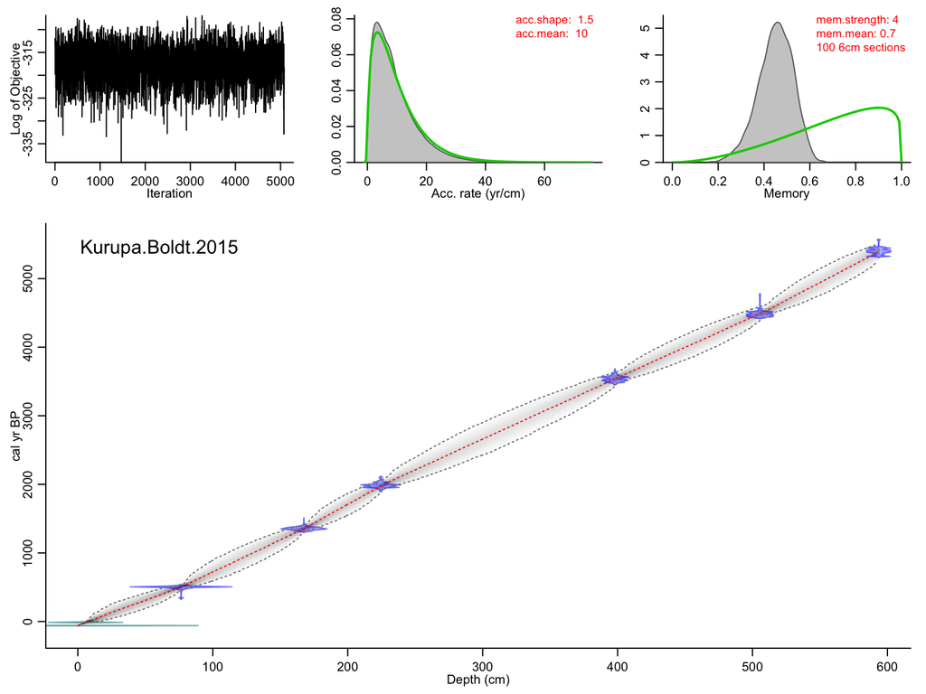

##And plot the ensemble output

```
## [1] "Found it! Moving on..."
## [1] "Found it! Moving on..."
## [1] "plotting your chron ensemble. This make take a few seconds..."
```

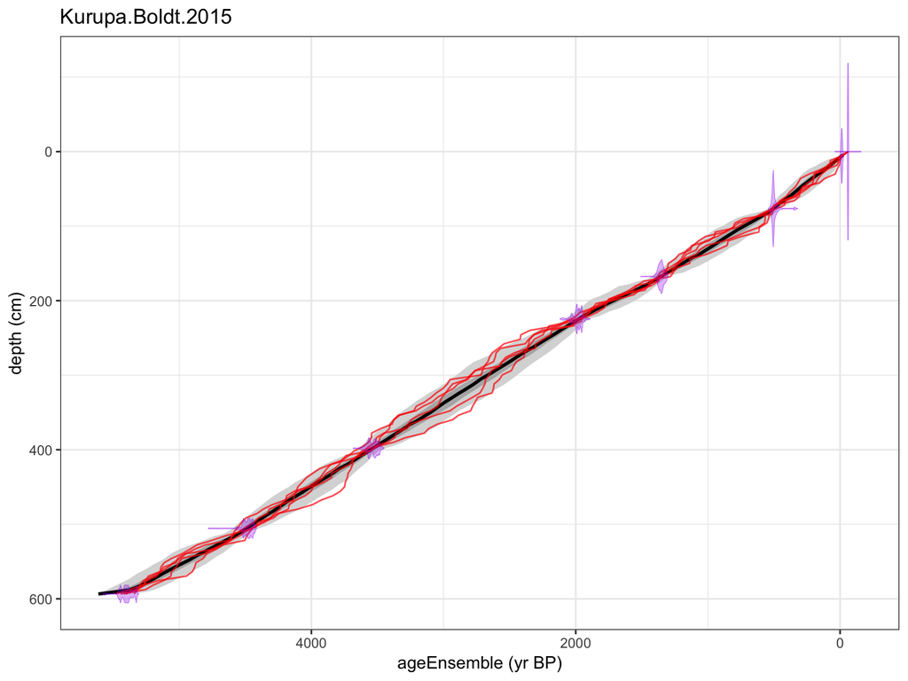

```r
plotChron(K,age.var = "ageEnsemble",distScale = 0.2)
```

##Map the age ensemble to the paleodata table This is to get ensemble age estimates for each depth in the paleoData measurement table

```r
K <- mapAgeEnsembleToPaleoData(K,age.var = "ageEnsemble")
```

```
## [1] "Kurupa.Boldt.2015"
## [1] "Looking for age ensemble...."
## [1] "Found it! Moving on..."
## [1] "Found it! Moving on..."
## [1] "getting depth from the paleodata table..."
## [1] "Found it! Moving on..."
```

##select the paleodata age ensemble, and RABD data that we’d like to regress and calibrate

```r
kae <-  selectData(K,"ageEnsemble")
```

```
## [1] "Found it! Moving on..."
```